# LME Analysis of PNs

#### Analysis of H F0

```
##
## Model found using nloptwrap after trying less strict control settings.
```

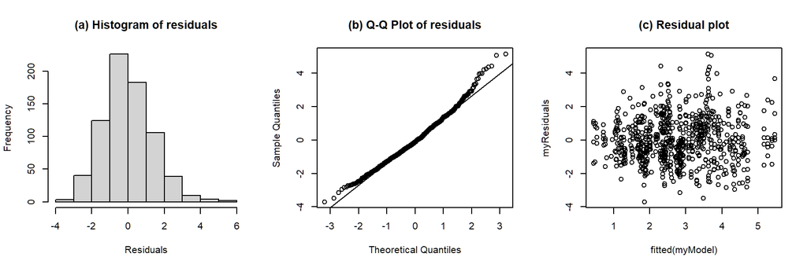

```
##
## Formula:
## h_f0 ~ acc_phon + ana_syls + foot_syls + wrd_end_syl + pn_new_word +, gender + (1 + foot_syls | speaker) + (1 | pn_str_syl)
##
## Linear mixed model fit by REML. t-tests use Satterthwaite's method [
## lmerModLmerTest]
## Formula: h_f0_equation
##    Data: pn_h_data
## Control:
## lmerControl(optCtrl = list(maxit = 1e+09, maxfun = 1e+09, xtol_abs = 1e-09,
##     ftol_abs = 1e-09))
##
## REML criterion at convergence: 2647.9
##
## Scaled residuals:
##     Min      1Q  Median      3Q     Max
## -2.6550 -0.6674 -0.0881  0.6258  3.6964
##
## Random effects:
##  Groups     Name        Variance Std.Dev. Corr
##  speaker    (Intercept) 0.6130   0.7829
##             foot_syls2  0.4397   0.6631    0.00
##             foot_syls3  0.1125   0.3354   -0.78  0.30
##             foot_syls4  0.9690   0.9844   -0.86 -0.12  0.48
##  pn_str_syl (Intercept) 0.3203   0.5660
##  Residual               1.9406   1.3931
## Number of obs: 737, groups:  speaker, 11; pn_str_syl, 8
##
## Fixed effects:
##                  Estimate Std. Error        df t value Pr(>|t|)
## (Intercept)       1.49572    0.50524  12.19988   2.960 0.011725 *
## acc_phon>H*       0.23633    0.22898 614.72866   1.032 0.302438
## acc_phonH*        0.03689    0.18036 540.08757   0.205 0.837994
## ana_syls1         0.29501    0.69493   3.15757   0.425 0.698466
## ana_syls2         0.36983    0.72834   4.05226   0.508 0.638006
## ana_syls3        -0.32741    0.73109   4.07293  -0.448 0.677060
## foot_syls2        0.74429    0.33802  21.08722   2.202 0.038940 *
## foot_syls3        1.02835    0.29662  31.26625   3.467 0.001554 **
## foot_syls4        0.67842    0.46586  32.14443   1.456 0.155016
## wrd_end_syl2      0.10564    0.24323 171.77696   0.434 0.664614
## wrd_end_syl3      0.13951    0.50846  20.25873   0.274 0.786579
## pn_new_wordTRUE  -0.83767    0.66641   3.40474  -1.257 0.288074
## genderM           1.41568    0.22636   9.42318   6.254 0.000122 ***
## ---
## Signif. codes:  0 '***' 0.001 '**' 0.01 '*' 0.05 '.' 0.1 ' ' 1
```

ANOVA of model: h_f0 ~ acc_phon + ana_syls + foot_syls + wrd_end_syl + pn_new_word +, gender + (1 + foot_syls | speaker) + (1 | pn_str_syl)

| term | sumsq | meansq | NumDF | DenDF | F value | p.value | p.adj (BH) | signif. |
| --- | --- | --- | --- | --- | --- | --- | --- | --- |
| acc_phon | 2.08 | 1.04 | 2 | 596.16 | 0.54 | .586 | .627 |  |
| ana_syls | 16.6 | 5.53 | 3 | 6.28 | 2.85 | .123 | .185 |  |
| foot_syls | 25.33 | 8.44 | 3 | 26.42 | 4.35 | .013 | .023 | *p* < .05 |
| wrd_end_syl | 0.37 | 0.19 | 2 | 33.21 | 0.1 | .909 | .909 |  |
| pn_new_word | 3.07 | 3.07 | 1 | 3.4 | 1.58 | .288 | .384 |  |
| gender | 75.9 | 75.9 | 1 | 9.42 | 39.11 | < .001 | < .001 | *p* < .05 |

Omega<sup>2</sup> (partial) for h_f0.

| Parameter | ω<sup>2</sup><sub>*p*</sub> | 95% CI |
| --- | --- | --- |
| acc_phon | 0 | [0, 0] |
| ana_syls | .35 | [0, .68] |
| foot_syls | .25 | [0, .46] |
| wrd_end_syl | 0 | [0, 0] |
| pn_new_word | .1 | [0, .66] |
| gender | .77 | [.38, .89] |

Conditional and marginal R<sup>2</sup>

| marginal R<sup>2</sup> | conditional R<sup>2</sup> |
| --- | --- |
| .23 | .46 |

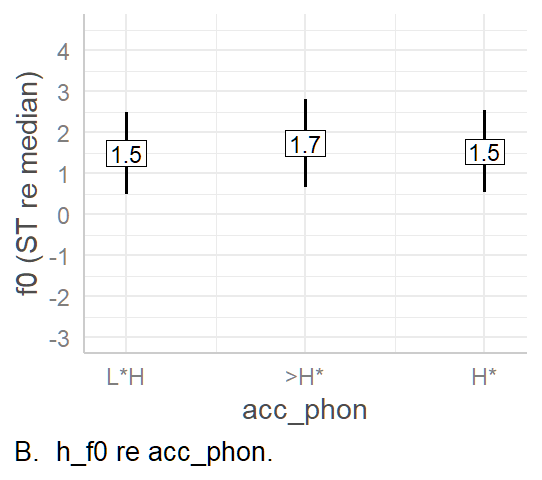

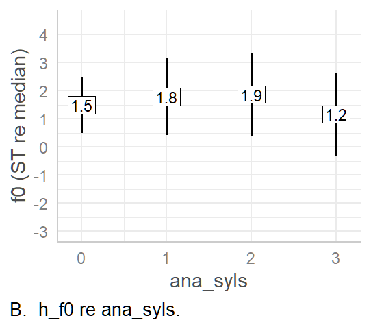

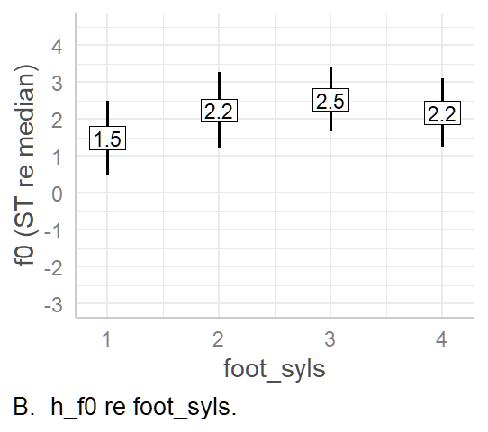

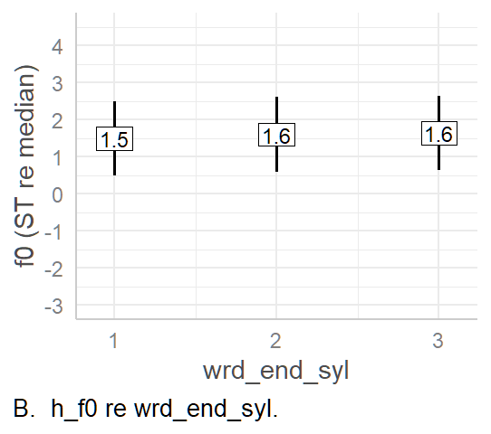

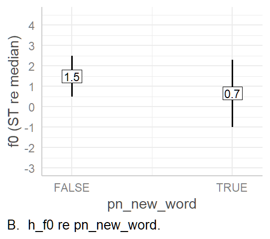

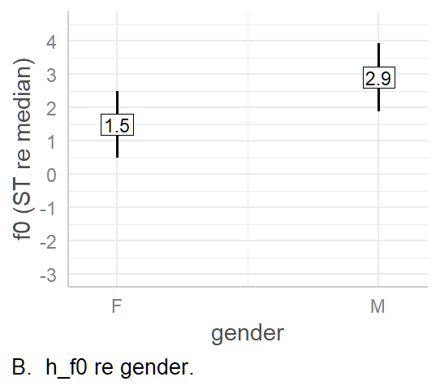

Predicted values of h_f0

| acc_phon | predicted | conf.low | conf.high | std.error |
| --- | --- | --- | --- | --- |
| L*H | 1.5 | 0.5 | 2.49 | 0.51 |
| &gt;H* | 1.73 | 0.66 | 2.8 | 0.54 |
| H* | 1.53 | 0.53 | 2.53 | 0.51 |

Predicted values of h_f0

| ana_syls | predicted | conf.low | conf.high | std.error |
| --- | --- | --- | --- | --- |
| 0 | 1.5 | 0.5 | 2.49 | 0.51 |
| 1 | 1.79 | 0.41 | 3.17 | 0.7 |
| 2 | 1.87 | 0.39 | 3.34 | 0.75 |
| 3 | 1.17 | -0.31 | 2.65 | 0.75 |

Predicted values of h_f0

| foot_syls | predicted | conf.low | conf.high | std.error |
| --- | --- | --- | --- | --- |
| 1 | 1.5 | 0.5 | 2.49 | 0.51 |
| 2 | 2.24 | 1.2 | 3.28 | 0.53 |
| 3 | 2.52 | 1.65 | 3.4 | 0.44 |
| 4 | 2.17 | 1.24 | 3.1 | 0.47 |

Predicted values of h_f0

| wrd_end_syl | predicted | conf.low | conf.high | std.error |
| --- | --- | --- | --- | --- |
| 1 | 1.5 | 0.5 | 2.49 | 0.51 |
| 2 | 1.6 | 0.59 | 2.62 | 0.52 |
| 3 | 1.64 | 0.64 | 2.64 | 0.51 |

Predicted values of h_f0

| pn_new_word | predicted | conf.low | conf.high | std.error |
| --- | --- | --- | --- | --- |
| FALSE | 1.5 | 0.5 | 2.49 | 0.51 |
| TRUE | 0.66 | -0.98 | 2.3 | 0.84 |

Predicted values of h_f0

| gender | predicted | conf.low | conf.high | std.error |
| --- | --- | --- | --- | --- |
| F | 1.5 | 0.5 | 2.49 | 0.51 |
| M | 2.91 | 1.89 | 3.93 | 0.52 |

h_f0 ~ acc_phon + ana_syls + foot_syls + wrd_end_syl + pn_new_word + gender + (1 + foot_syls | speaker) + (1 | pn_str_syl)

b1: h_f0 ~ acc_phon + ana_syls + foot_syls + wrd_end_syl + pn_new_word +, gender + (1 + foot_syls | speaker) + (1 | pn_str_syl)

| intercept | slope | estimate | conf.low | conf.high | std.error | t.value | df | p.value |
| --- | --- | --- | --- | --- | --- | --- | --- | --- |
| acc_phonL*H | acc_phon>H* | 0.2 | -0.2 | 0.7 | 0.23 | 1.03 | 614.73 | .302 |
| acc_phonL*H | acc_phonH* | 0.0 | -0.3 | 0.4 | 0.18 | 0.2 | 540.09 | .838 |
| acc_phon>H* | acc_phonH* | -0.2 | -0.7 | 0.3 | 0.25 | -0.8 | 686.56 | .426 |
| ana_syls0 | ana_syls1 | 0.3 | -1.9 | 2.4 | 0.69 | 0.42 | 3.16 | .698 |
| ana_syls0 | ana_syls2 | 0.4 | -1.6 | 2.4 | 0.73 | 0.51 | 4.05 | .638 |
| ana_syls0 | ana_syls3 | -0.3 | -2.3 | 1.7 | 0.73 | -0.45 | 4.07 | .677 |
| ana_syls1 | ana_syls2 | 0.1 | -0.4 | 0.6 | 0.26 | 0.29 | 604.75 | .772 |
| ana_syls1 | ana_syls3 | -0.6 | -1.1 | -0.1 | 0.26 | -2.39 | 625.76 | .017 |
| ana_syls2 | ana_syls3 | -0.7 | -1.2 | -0.2 | 0.26 | -2.64 | 677.79 | .009 |
| foot_syls1 | foot_syls2 | 0.7 | 0.0 | 1.4 | 0.34 | 2.2 | 21.09 | .039 |
| foot_syls1 | foot_syls3 | 1.0 | 0.4 | 1.6 | 0.3 | 3.47 | 31.27 | .002 |
| foot_syls1 | foot_syls4 | 0.7 | -0.3 | 1.6 | 0.47 | 1.46 | 32.14 | .155 |
| foot_syls2 | foot_syls3 | 0.3 | -0.4 | 0.9 | 0.32 | 0.88 | 29.25 | .384 |
| foot_syls2 | foot_syls4 | -0.1 | -1.1 | 1.0 | 0.51 | -0.13 | 24.28 | .898 |
| foot_syls3 | foot_syls4 | -0.3 | -1.1 | 0.4 | 0.36 | -0.96 | 23.85 | .346 |
| wrd_end_syl1 | wrd_end_syl2 | 0.1 | -0.4 | 0.6 | 0.24 | 0.43 | 171.78 | .665 |
| wrd_end_syl1 | wrd_end_syl3 | 0.1 | -0.9 | 1.2 | 0.51 | 0.27 | 20.26 | .787 |
| wrd_end_syl2 | wrd_end_syl3 | 0.0 | -0.9 | 1.0 | 0.43 | 0.08 | 14.01 | .939 |
| intercept | pn_new_wordT | -0.8 | -2.8 | 1.1 | 0.67 | -1.26 | 3.4 | .288 |
| intercept | genderM | 1.4 | 0.9 | 1.9 | 0.23 | 6.25 | 9.42 | < .001 |

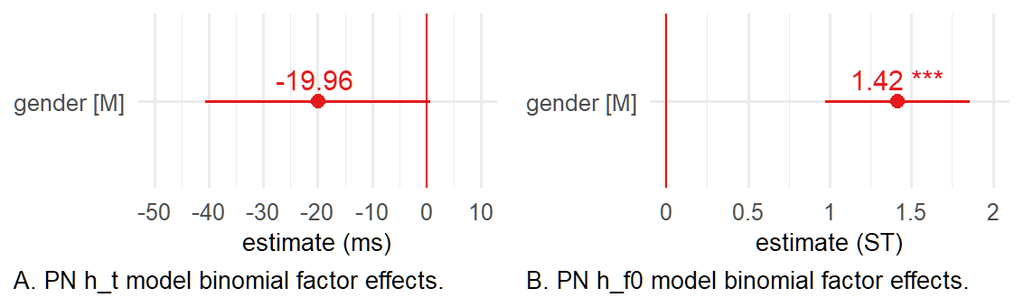

### Truncation and Compression

Based on results from tonal target analysis, it looks there is an element of truncation in LH contours as a function of foot size, alongside a degree of rightward drift in L targets as foot size increases. However, superficially, it looks like the slope is stable.

As with nuclear data, I am retaining the overall model structure as much as possible BUT will discard all but foot_syls for analysis.

#### LH Excursion

```
##
## Model found using optimx after trying original model.
```

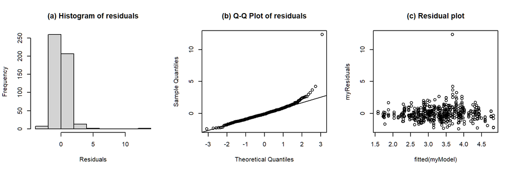

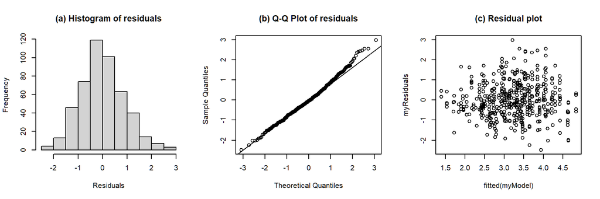

```
##
## Formula:
## f0_exc ~ foot_syls + (1 | speaker) + (1 | ana_syls) + (1 | gender) +, (1 | pn_str_syl)
##
## Linear mixed model fit by REML. t-tests use Satterthwaite's method [
## lmerModLmerTest]
## Formula: f0_exc_equation
##    Data: pn_f0_exc.trimmed
## Control:
## lmerControl(optimizer = optimizer, calc.derivs = F, optCtrl = list(method = "nlminb",
##     starttests = F, kkt = F))
##
## REML criterion at convergence: 1321.3
##
## Scaled residuals:
##     Min      1Q  Median      3Q     Max
## -2.7738 -0.6537 -0.0548  0.5866  3.3266
##
## Random effects:
##  Groups     Name        Variance Std.Dev.
##  speaker    (Intercept) 0.1681   0.4100
##  pn_str_syl (Intercept) 0.5206   0.7215
##  ana_syls   (Intercept) 0.1643   0.4053
##  gender     (Intercept) 0.1091   0.3302
##  Residual               0.8003   0.8946
## Number of obs: 484, groups:  speaker, 11; pn_str_syl, 8; ana_syls, 4; gender, 2
##
## Fixed effects:
##             Estimate Std. Error       df t value Pr(>|t|)
## (Intercept)   2.3543     0.4739   7.0995   4.968 0.001558 **
## foot_syls2    0.5798     0.2549 331.4416   2.274 0.023578 *
## foot_syls3    0.8813     0.2445 320.7600   3.605 0.000362 ***
## foot_syls4    0.6131     0.2991 256.6059   2.050 0.041413 *
## ---
## Signif. codes:  0 '***' 0.001 '**' 0.01 '*' 0.05 '.' 0.1 ' ' 1
##
## Correlation of Fixed Effects:
##            (Intr) ft_sy2 ft_sy3
## foot_syls2 -0.345
## foot_syls3 -0.365  0.624
## foot_syls4 -0.344  0.513  0.797
```

ANOVA of model: f0_exc ~ foot_syls + (1 | speaker) + (1 | ana_syls) + (1 | gender) +, (1 | pn_str_syl)

| term | sumsq | meansq | NumDF | DenDF | F value | p.value | p.adj (BH) | signif. |
| --- | --- | --- | --- | --- | --- | --- | --- | --- |
| foot_syls | 11.89 | 3.96 | 3 | 306.15 | 4.95 | .002 | .005 | *p* < .05 |

Omega<sup>2</sup> (partial) for f0_exc.

| Parameter | ω<sup>2</sup><sub>*p*</sub> | 95% CI |
| --- | --- | --- |
| foot_syls | .04 | [0, .08] |

Conditional and marginal R<sup>2</sup>

| marginal R<sup>2</sup> | conditional R<sup>2</sup> |
| --- | --- |
| .03 | .56 |

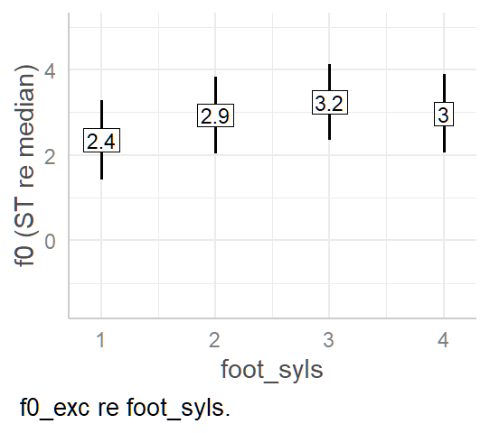

Predicted values of f0_exc

| foot_syls | predicted | conf.low | conf.high | std.error |
| --- | --- | --- | --- | --- |
| 1 | 2.35 | 1.42 | 3.29 | 0.47 |
| 2 | 2.93 | 2.04 | 3.83 | 0.45 |
| 3 | 3.24 | 2.36 | 4.11 | 0.45 |
| 4 | 2.97 | 2.05 | 3.88 | 0.47 |

f0_exc ~ foot_syls + (1 | speaker) + (1 | ana_syls) + (1 | gender) + (1 | pn_str_syl)

b1: f0_exc ~ foot_syls + (1 | speaker) + (1 | ana_syls) + (1 | gender) +, (1 | pn_str_syl)

| intercept | slope | estimate | conf.low | conf.high | std.error | t.value | df | p.value |
| --- | --- | --- | --- | --- | --- | --- | --- | --- |
| foot_syls1 | foot_syls2 | 0.6 | 0.1 | 1.1 | 0.25 | 2.27 | 331.44 | .024 |
| foot_syls1 | foot_syls3 | 0.9 | 0.4 | 1.4 | 0.24 | 3.6 | 320.76 | < .001 |
| foot_syls1 | foot_syls4 | 0.6 | 0.0 | 1.2 | 0.3 | 2.05 | 256.61 | .041 |
| foot_syls2 | foot_syls3 | 0.3 | -0.1 | 0.7 | 0.22 | 1.39 | 274.89 | .166 |
| foot_syls2 | foot_syls4 | 0.0 | -0.5 | 0.6 | 0.28 | 0.12 | 216.89 | .904 |
| foot_syls3 | foot_syls4 | -0.3 | -0.6 | 0.1 | 0.18 | -1.48 | 403.29 | .139 |

#### LH Slope

```
## Searching for good optimization settings with optimizeModel().
##   Formula:   log_lh_slope ~ +foot_syls + (1 | speaker) + (1 | gender) + (1 |, ana_syls) + (1 | pn_str_syl) + (1 | wrd_end_syl)
##   Optimizer: optimx
##
## Model found using optimx after trying original model.
```

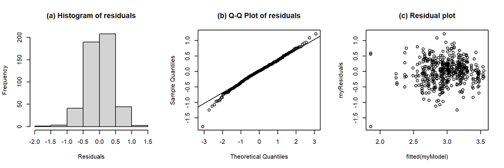

```
##
## Running step() ...
## Model found: log_lh_slope ~ (1 | speaker) + (1 | gender) + (1 | pn_str_syl) +, (1 | wrd_end_syl)
```

- data needs trimming: residual SD > 4

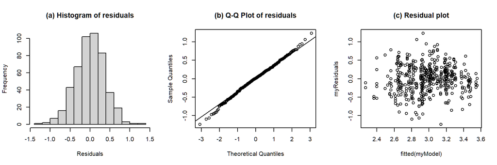

```
##
## Formula:
## log_lh_slope ~ +foot_syls + (1 | speaker) + (1 | gender) + (1 |, ana_syls) + (1 | pn_str_syl) + (1 | wrd_end_syl)
##
## Linear mixed model fit by REML. t-tests use Satterthwaite's method [
## lmerModLmerTest]
## Formula: lh_slope_equation
##    Data: pn_lh_slope.trimmed
## Control:
## lmerControl(optimizer = optimizer, calc.derivs = F, optCtrl = list(method = "nlminb",
##     starttests = F, kkt = F))
##
## REML criterion at convergence: 487.2
##
## Scaled residuals:
##     Min      1Q  Median      3Q     Max
## -3.2743 -0.6077  0.0234  0.6262  3.2717
##
## Random effects:
##  Groups      Name        Variance Std.Dev.
##  speaker     (Intercept) 0.021199 0.14560
##  pn_str_syl  (Intercept) 0.054258 0.23293
##  ana_syls    (Intercept) 0.003308 0.05751
##  wrd_end_syl (Intercept) 0.007067 0.08406
##  gender      (Intercept) 0.032796 0.18110
##  Residual                0.142094 0.37695
## Number of obs: 488, groups:
## speaker, 11; pn_str_syl, 8; ana_syls, 4; wrd_end_syl, 3; gender, 2
##
## Fixed effects:
##             Estimate Std. Error       df t value Pr(>|t|)
## (Intercept)   3.0281     0.1923   3.5949  15.747 0.000191 ***
## foot_syls2   -0.1802     0.1050 191.3782  -1.716 0.087761 .
## foot_syls3   -0.1661     0.1006 177.0656  -1.651 0.100445
## foot_syls4   -0.1807     0.1222 130.3603  -1.478 0.141837
## ---
## Signif. codes:  0 '***' 0.001 '**' 0.01 '*' 0.05 '.' 0.1 ' ' 1
##
## Correlation of Fixed Effects:
##            (Intr) ft_sy2 ft_sy3
## foot_syls2 -0.340
## foot_syls3 -0.375  0.623
## foot_syls4 -0.359  0.516  0.792
```

ANOVA of model: log_lh_slope ~ +foot_syls + (1 | speaker) + (1 | gender) + (1 |, ana_syls) + (1 | pn_str_syl) + (1 | wrd_end_syl)

| term | sumsq | meansq | NumDF | DenDF | F value | p.value | p.adj (BH) | signif. |
| --- | --- | --- | --- | --- | --- | --- | --- | --- |
| foot_syls | 0.5 | 0.17 | 3 | 184.88 | 1.19 | .317 | .407 |  |

Omega<sup>2</sup> (partial) for log_lh_slope.

| Parameter | ω<sup>2</sup><sub>*p*</sub> | 95% CI |
| --- | --- | --- |
| foot_syls | 0 | [0, .02] |

Conditional and marginal R<sup>2</sup>

| marginal R<sup>2</sup> | conditional R<sup>2</sup> |
| --- | --- |
| .01 | .46 |

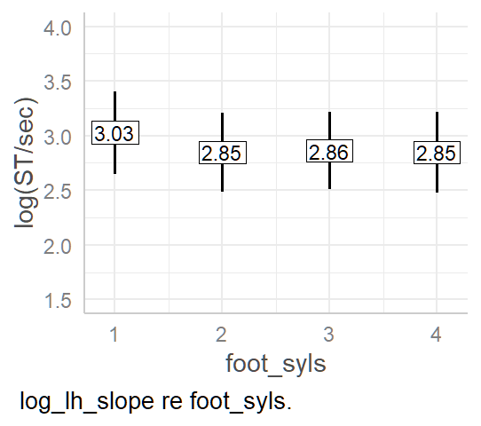

Predicted values of log_lh_slope

| foot_syls | predicted | conf.low | conf.high | std.error |
| --- | --- | --- | --- | --- |
| 1 | 3.03 | 2.65 | 3.41 | 0.19 |
| 2 | 2.85 | 2.48 | 3.21 | 0.19 |
| 3 | 2.86 | 2.51 | 3.22 | 0.18 |
| 4 | 2.85 | 2.48 | 3.22 | 0.19 |

log_lh_slope ~ +foot_syls + (1 | speaker) + (1 | gender) + (1 | ana_syls) + (1 | pn_str_syl) + (1 | wrd_end_syl)

b1: log_lh_slope ~ +foot_syls + (1 | speaker) + (1 | gender) + (1 |, ana_syls) + (1 | pn_str_syl) + (1 | wrd_end_syl)

| intercept | slope | estimate | conf.low | conf.high | std.error | t.value | df | p.value |
| --- | --- | --- | --- | --- | --- | --- | --- | --- |
| foot_syls1 | foot_syls2 | -0.18 | -0.39 | 0.03 | 0.11 | -1.72 | 191.38 | .088 |
| foot_syls1 | foot_syls3 | -0.17 | -0.36 | 0.03 | 0.1 | -1.65 | 177.07 | .1 |
| foot_syls1 | foot_syls4 | -0.18 | -0.42 | 0.06 | 0.12 | -1.48 | 130.36 | .142 |
| foot_syls2 | foot_syls3 | 0.01 | -0.16 | 0.19 | 0.09 | 0.16 | 179.65 | .875 |
| foot_syls2 | foot_syls4 | 0.00 | -0.22 | 0.22 | 0.11 | 0 | 127.43 | .997 |
| foot_syls3 | foot_syls4 | -0.01 | -0.16 | 0.13 | 0.07 | -0.19 | 290.3 | .846 |

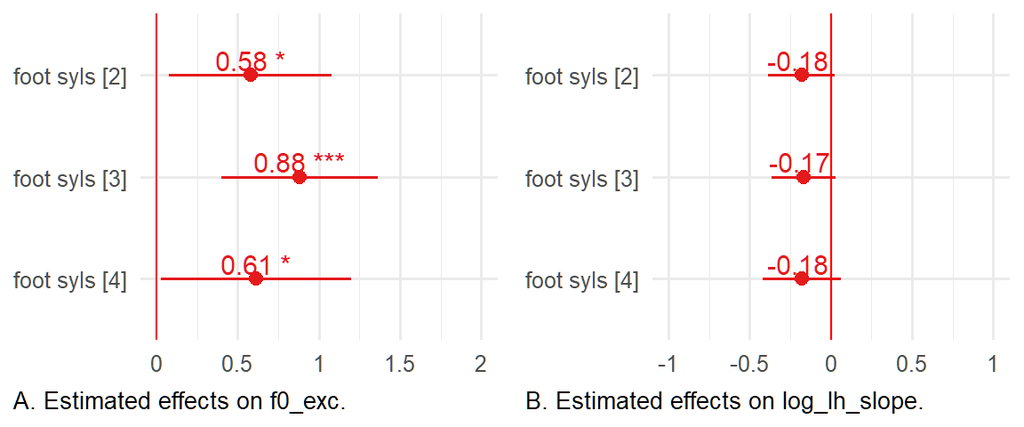